# Exploration

## Comment

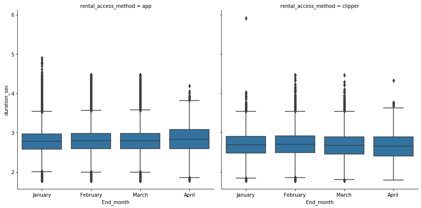

```python
# Multivariate box plot of end month and duration in second hued by rental_access_method
import warnings
warnings.filterwarnings('ignore')
warnings.simplefilter('ignore')
plt.figure(figsize = [15, 5])
g = sns.FacetGrid(data = df_merged, col = 'rental_access_method', size = 6)
g.map(sns.boxplot, 'End_month', 'duration_sec');
```

## Comment

```python
df_merged_new = df_merged[(df_merged.start_station_latitude >= 37.2) & (df_merged.start_station_latitude <= 38)]
df_merged_new = df_merged_new[(df_merged_new.end_station_latitude >= 37.2) & (df_merged_new.end_station_latitude <= 38)]
```

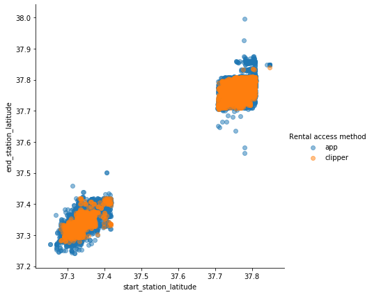

```python
g = sns.FacetGrid(data = df_merged_new, hue = 'rental_access_method', size = 6)
g.map(plt.scatter, 'start_station_latitude', 'end_station_latitude', alpha = 0.5)
g.add_legend(title = 'Rental access method');
```

## Comment

> The chart above show the distribution of the start station latitude and end station latitude by rental access method. From the scatter plot above, we can See that data point for both category of the rental access method follows the same distribution. There were also outliers detected in **app** category of the rental access method.

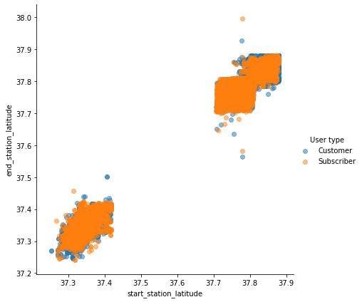

```python
g = sns.FacetGrid(data = df_merged_new, hue = 'user_type', size = 6)
g.map(plt.scatter, 'start_station_latitude', 'end_station_latitude', alpha = 0.5)
g.add_legend(title = 'User type');
```

## Comment

> The chart above show the distribution of the start station latitude and end station latitude by user. From the scatter plot above, we can See that data point for both category of the user type follows the same distribution. There were few outliers detected in **customer** and **subscriber** category of the user type.

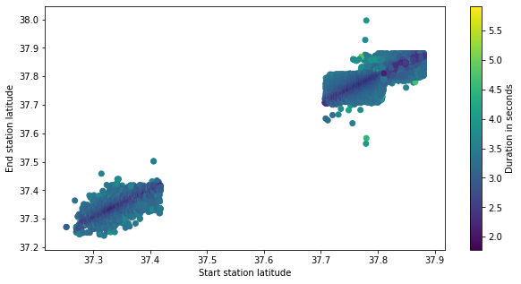

```python
plt.figure(figsize= [10, 5])
plt.scatter(data = df_merged_new, x = 'start_station_latitude', y = 'end_station_latitude', c = 'duration_sec',
            cmap = 'viridis')
plt.colorbar(label = 'Duration in seconds');
plt.xlabel('Start station latitude')
plt.ylabel('End station latitude');
```

## Comment

> The chart above show the distribution of the start station latitude and end station latitude by duration in seconds. From the scatter plot above, we can See that data points where separated in two category. Also, from the chart above, majority of the data point has duration in seconds less tham 4.5seconds. there where few outliers detected.